# Matt Melnychuk’s Midterm for R 421

```r
model2 <- train(targetB~., data=df3_train,
                    method = "pam",
                                trControl = trControl)
```

```
## 123456789101112131415161718192021222324252627282930111111
```

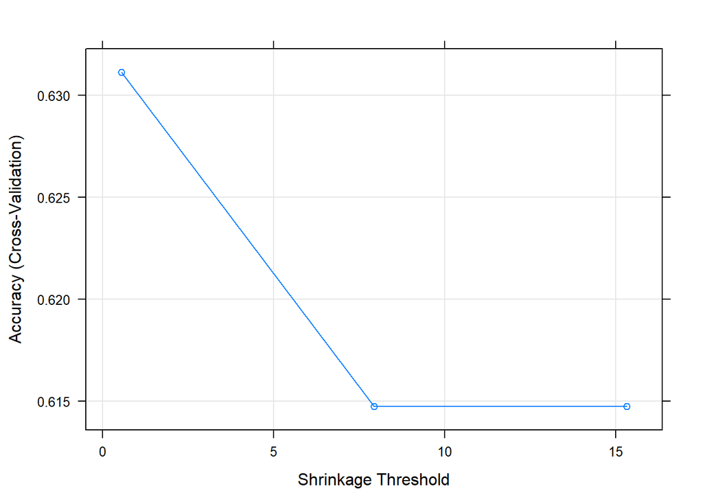

```r
plot(model2)
```

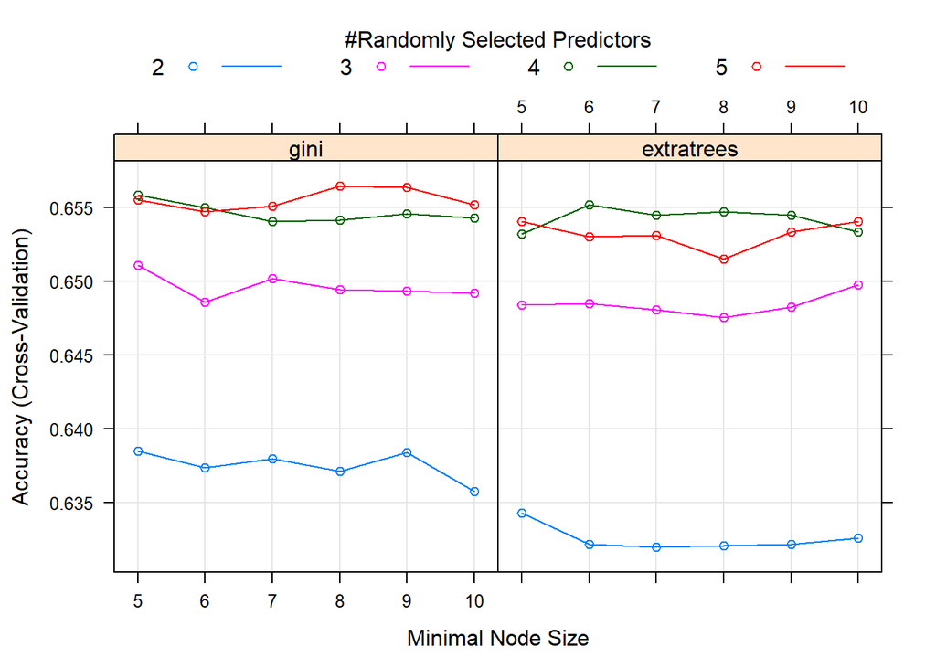

```r
tuneGrid = expand.grid(mtry = 2:5,
                       splitrule = c('gini', 'extratrees'),
                       min.node.size = c(5:10))
set.seed(2020)
model3 <- train(targetB~., data=df3_train,
                    method = "ranger",
                    trControl = trControl,
                    tuneGrid = tuneGrid)
plot(model3)
```

It appears that five predictors leads to the best models, and the gini split is better than the extra trees split again, but not by as much as when predicting high/low cost.

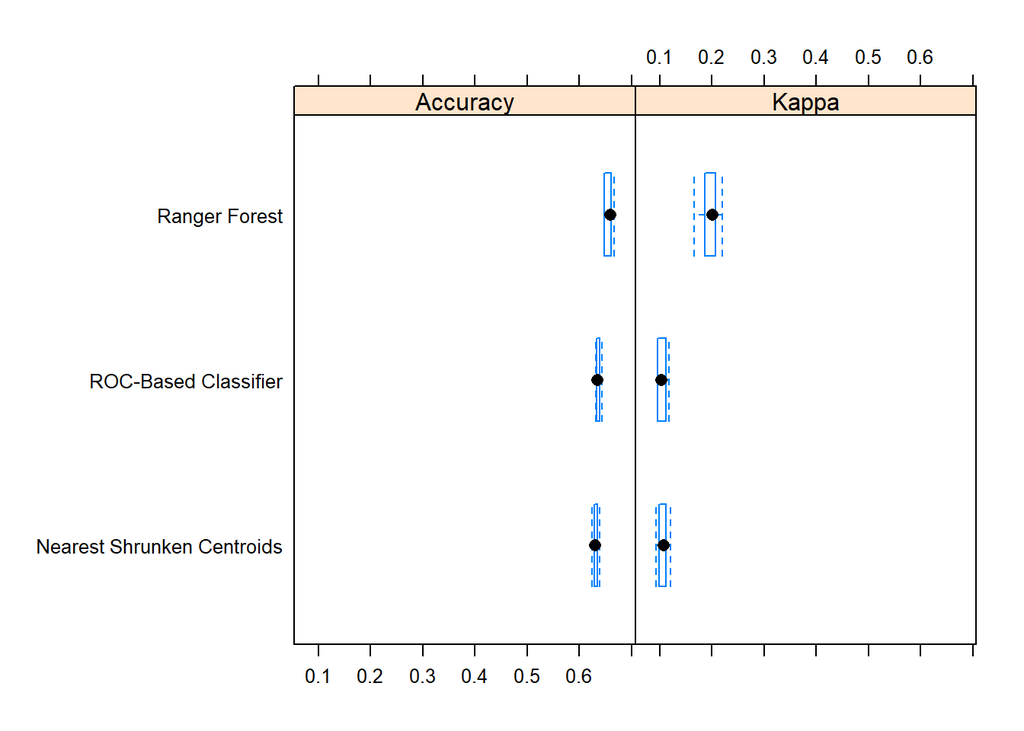

```r
results <- resamples(list('ROC-Based Classifier' = model1,
                          'Nearest Shrunken Centroids'= model2,
                          'Ranger Forest'=model3))
bwplot(results)
```

Again, the random forest `ranger` model outperforms the others, but the models are now much closer in accuracy.

My selection is to use the `ranger` method of creating a random forest with `gini` splits, `5 predictors`, and a `minimum node size of 8`.

```r
tuneGrid = expand.grid(mtry = 5:5,
                       splitrule = c('gini'),
                       min.node.size = c(8:8))
set.seed(2020)
model3 <- train(targetB~., data=df3_train,
                    method = "ranger",
                    trControl = trControl,
                    tuneGrid = tuneGrid)

pred <- predict(model3, df3_test)
cm <- confusionMatrix(data = pred, reference = df3_test$targetB, positive = "high")
cm$overall[1]
```

```
##  Accuracy
## 0.6551193
```

The overall accuracy of this model is `65.5%`.

7. Write a paragraph to summarize the section and give your comments on the results.

The clean dataset is still far too large for the random forest models, so I used a reduced data set in questions 3-5 that captured abouth a tenth of the original data (13,000 rows). Throughout the models, it appeared like `length of stay` and `total cost` have a strong correlation, which is not surprising. The context of the `admittance type` is also very important in determining how long a patient stays and how much it costs. The most interesting discovery was that going to different hospitals seems to have an impact on how long a patient stays for. This is probably explained by the fact that certain hospitals have different specialties, and it is very possible that if a patient knows they will be in the hospital for a long time they would select a different hospital than if they were going in for a one-day procedure. It is good to see that `race/ethnicity` and `sex` do not have an impact in the model because those should not impact how much a person pays or how long it takes (in general) to treat a patient.